# MW ESM 244 HW 3

#### b. Forecasting using Holt-Winters

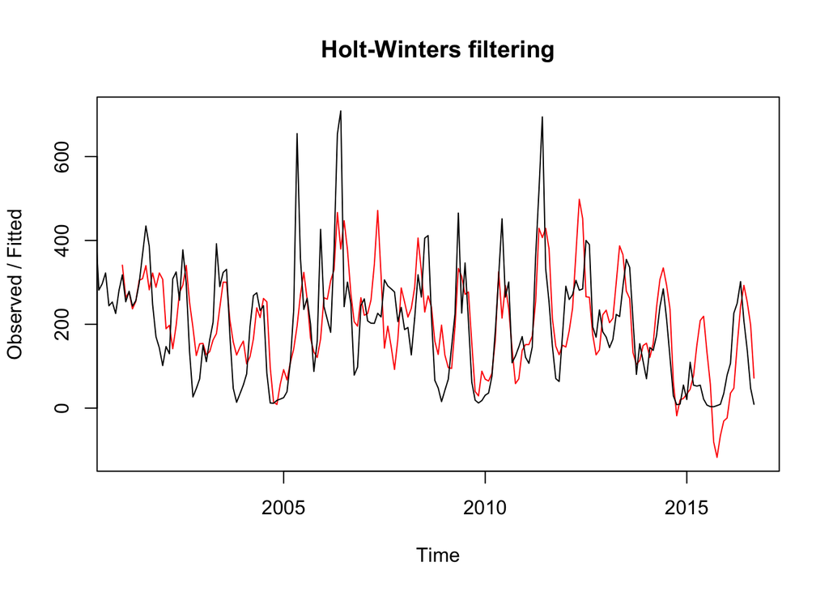

```r
flow_hw <- HoltWinters(flow_ts)
# flow_hw  # check smoothing parameters
plot(flow_hw)
```

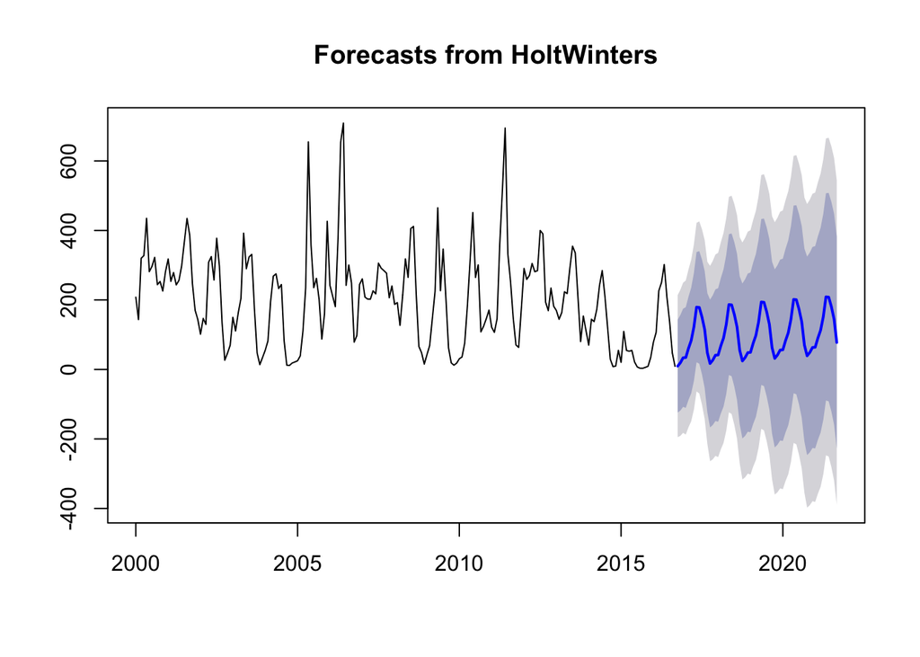

```r
# Then forecast
flow_forecast <- forecast(flow_hw, h = 60) #forecasts 60 periods, or 5 years
plot(flow_forecast) # blue lines are model predictions, grey shows the 80% and 95% confidence intervals for predicted value
```

#### c. Assessment of residuals

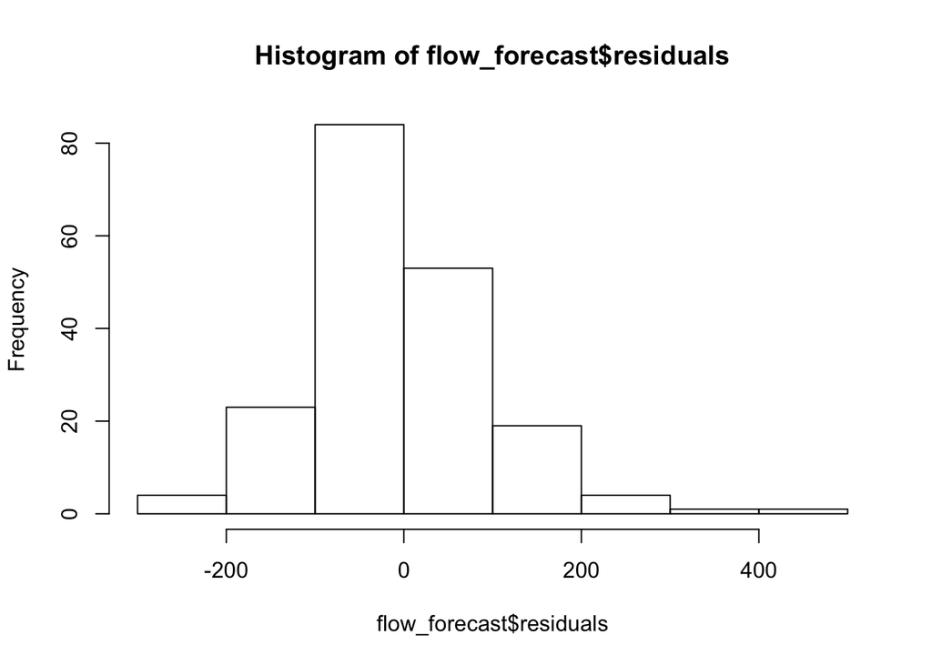

```r
hist(flow_forecast$residuals)
```

The residuals appear to be normally distributed, with no cause for concern about bias or poor model fit.

### Task 3: Mapping CA’s National Parks

#### *Load packages and data*

```r
library(tidyverse)
library(sf)
library(leaflet)
library(ggrepel)
library(ggspatial)
library(rgdal)

# Read in shapefiles for park boundaries and CA counties:
ca_park_sf <- read_sf(".", layer = "nps_boundary") %>%
  filter(STATE == "CA")

ca_counties <- read_sf(".", layer = "california_county_shape_file")
```

#### Create map of parks in CA with labels

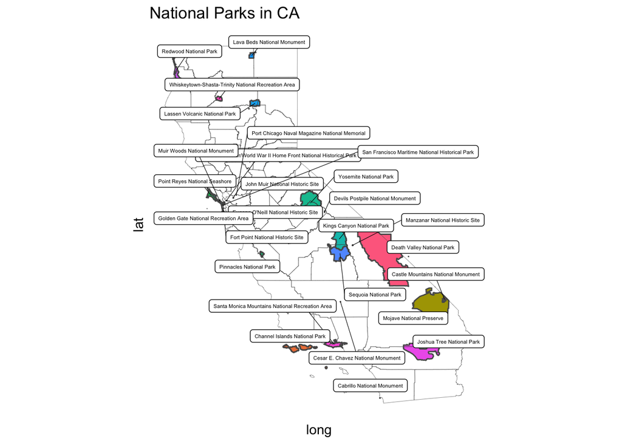

```r
# Set CRS of both layers:
st_crs(ca_counties) = 4326
st_crs(ca_park_sf) = 4326

# Get centroid point coordinates
centroids <- sf::st_centroid(ca_park_sf$geometry)

# Create new data frame with merged lat/longs of centroids and park names:
centroid_coords <- as.data.frame(sf::st_coordinates(centroids)) %>%
  add_column(ca_park_sf$UNIT_NAME)

colnames(centroid_coords) <- c("long", "lat", "park_name")


# Create a labeled map of parks:
ggplot(ca_park_sf) +
  geom_sf(aes(fill = GNIS_ID),
          show.legend = FALSE) +
  geom_sf(data = ca_counties,
          fill = "NA",
          color = "gray30",
          size = 0.1) +
  theme_minimal() +
  coord_sf(datum=NA) +
  labs(title = "National Parks in CA") +
  geom_label_repel(data = centroid_coords,
                   aes(x=long, y=lat, label = park_name),
                   size = 1.5,
                   force = 25,
                   nudge_y = 0.05,
                   segment.size = 0.2)
```

### Task 4: Desert Lizards

#### *Load packages and data*

```r
library(tidyverse)
library(pwr)
library(effsize)

lizards <- read_csv("lter_lizard_pitfall.csv") %>%
  dplyr::filter(weight != ".") %>%
  dplyr::filter(site == "CALI") %>%
  dplyr::filter(tail != ".") %>%
  dplyr::filter(sex != "J") %>%
  dplyr::filter(sex != ".")
```

#### Wrangle & explore data

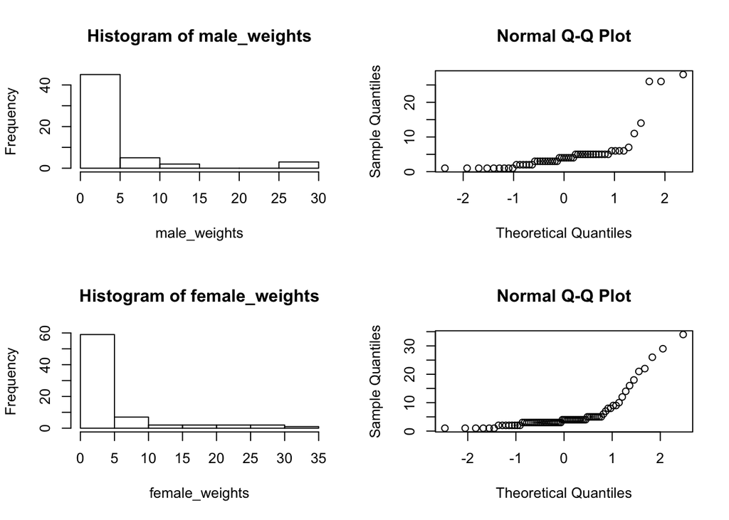

```r
# Change weight column to numeric:
lizards$weight <- as.numeric(lizards$weight)

# Create vectors of weights for males and females:
males <- lizards %>%
  dplyr::filter(sex == "M")

male_weights <- as.vector(males$weight)

females <- lizards %>%
  dplyr::filter(sex == "F")

female_weights <- as.vector(females$weight)

# Look at data distributions for each:
par(mfrow = c(2,2))
hist(male_weights)
qqnorm(male_weights)
hist(female_weights)
qqnorm(female_weights)
```

```r
# Data do not appear to be normally distributed for either sex
```

#### 1. Perform t-test to compare mean weight between males and females

```r
# Make columns into vectors:

t_test <- t.test(male_weights, female_weights)
t_test
```

```
##
##  Welch Two Sample t-test
##
## data:  male_weights and female_weights
## t = -0.6825, df = 123.53, p-value = 0.4962
## alternative hypothesis: true difference in means is not equal to 0
## 95 percent confidence interval:
##  -2.869579  1.398063
## sample estimates:
## mean of x mean of y
##  5.090909  5.826667
```

The mean weights for samples of male (n=55) and female (n=75) lizards trapped in California were not found to be significantly different using a Welch’s two sample t-test (p = 0.49, t(123) = -0.6825). Mean weights were 5.09 grams for males and 5.83 grams for females.

#### 2. Perform Chi-square test to compare broken tails

```r
# Look at proportions
tail_table <- table(lizards$sex, lizards$tail)
tail_table
```

```
##
##      B  W
##   F 17 58
##   M 10 45
```

```r
tail_prop <- prop.table(tail_table)
tail_prop
```

```
##
##              B          W
##   F 0.13076923 0.44615385
##   M 0.07692308 0.34615385
```

```r
# Perform Chi-square

males_tails <- c(10, 45)
females_tails <- c(17,58)
tails <- rbind(males_tails, females_tails)
colnames(tails) <- c("B", "W")


tails_chisq <- chisq.test(tails)
tails_chisq
```

```
##
##  Pearson's Chi-squared test with Yates' continuity correction
##
## data:  tails
## X-squared = 0.16319, df = 1, p-value = 0.6862
```

Performing a Pearson’s Chi-square test on proportions of male and female lizards with broken tails captured in California did not reveal a significant difference (p = 0.69, $\chi$<sup>2</sup>(1) = 0.163)